# Exercise 3 Solution

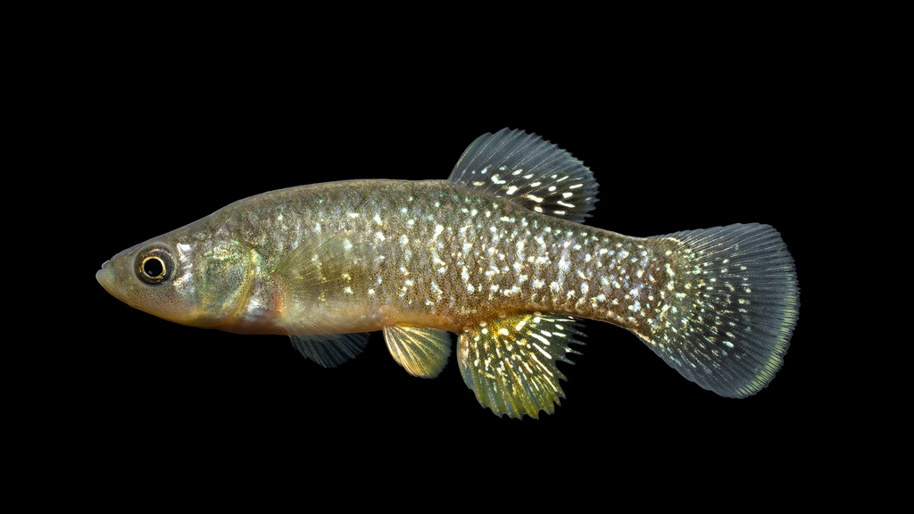

Here is the killifish, Fundulus heteroclitus. This is a small marsh species that is one of the most abundant species in estuaries along the east coast of the United States. Their common name is mud minnow or Mummichog, which means something along the lines of “going in crowds”. Despite being small (<10 cm), they’re super tough and tolerate all type of temperatures, salinity, hypoxia, pollution, and so on. They’re also cool because they don’t really move much. An average individual won’t leave its marsh during its lifetime. This means there should be lots of populations structure!

In this exercise you’re going to look at two common ways of assessing population structure: Principle components analysis and Structure. You’ll use RADseq data from 6 populations of F. heteroclitus. You’ll be using data from ~15,000 SNPs.

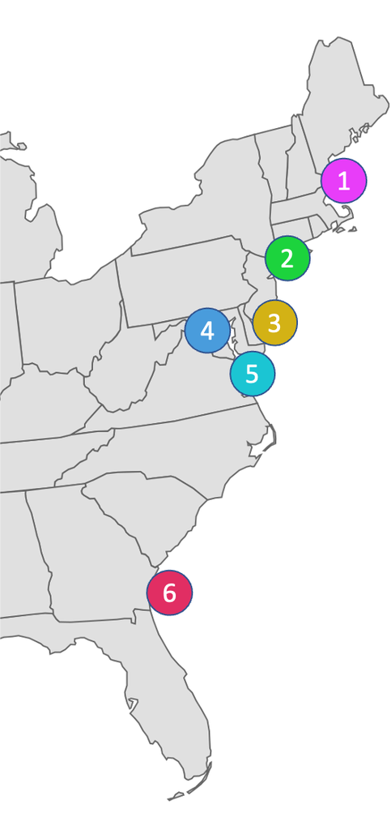

Collection sites for samples. N at each site is ~40. Note that all populations are brackish/marine except population 4, which is in fresh water.

```r
library(pophelper)
library(gridExtra)
library(ggplot2)
library(adegenet)
library(hierfstat)

# install heirfstat with:
#library(devtools)
#install_github("jgx65/hierfstat")
#library("hierfstat")

###################
# PCA
###################

# read in from structure format

obj <- read.structure("~/Documents/GEOMAR/Teaching/Mar_pop_gen/pca/fheteroclitus_coastal.pops.stru",
                      n.ind=239,
                      n.loc= 15542,
                      onerowperind = TRUE,
                      col.lab = 1,
                      col.pop = 2,
                      row.marknames=1,
                      col.others=FALSE,
                      NA.char = "0")
```

```
##
##  Converting data from a STRUCTURE .stru file to a genind object...
```

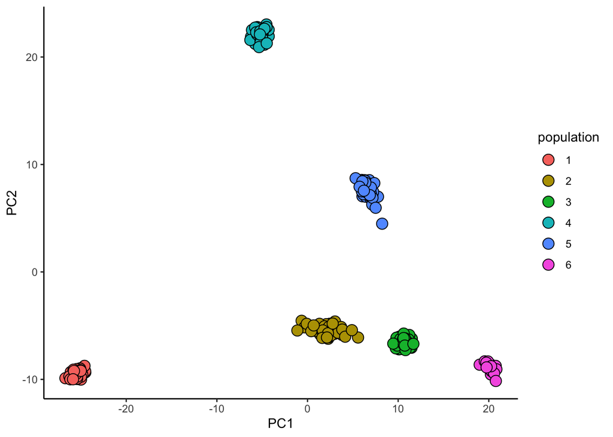

```r
pop(obj) <- substr(indNames(obj), 1,2)
# replace the population names with the corresponding numbers from the map. Just to make it easier to interpret
pop(obj)<- gsub("TR", "1",pop(obj))
pop(obj)<- gsub("PC", "2",pop(obj))
pop(obj)<- gsub("HP", "3",pop(obj))
pop(obj)<- gsub("PP", "4",pop(obj))
pop(obj)<- gsub("PL", "5",pop(obj))
pop(obj)<- gsub("GA", "6",pop(obj))

x.af <- tab(obj, freq=TRUE, NA.method="mean")
# 1 for an homozygote and 0.5 for an heterozygote.

pca.af <- dudi.pca(df = x.af, center = TRUE, # center by the mean
                   scale = FALSE, # don't scal/normalize,
                   scannf = FALSE, # don't show scree plot
                   nf = 10) # keep 5 pc's)

plot_data <- data.frame(individual = row.names(pca.af$li),
                        population = pop(obj),
                        PC1 = pca.af$li[,1],
                        PC2 = pca.af$li[,2]
)
plot_data$population <- factor(plot_data$population, levels = c("1","2","3","4","5","6"))


ggplot(plot_data, aes(x=PC1, y=PC2, fill=population)) +
  geom_point(size=4, shape=21) +
  theme_classic()
```

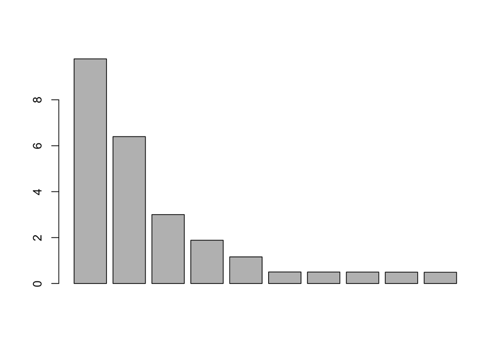

```r
eig.perc <- 100*pca.af$eig/sum(pca.af$eig)
barplot(eig.perc[1:10],)
```

#### Question 3.1

1. Do you think there is evidence for population structure in the data?
2. Which principle components would you present for these data? How would you choose?

### Genetic distance

Now you can calculate genetic distance as Cavalli-Sforza and Edwards Chord distance. The code below does this in a pairwise manner for all populations.

```r
dist.out <-genet.dist(obj, method = "Dch") # you can change the method here if you'd like. TH
dist.out
```

```
##            1          2          3          4          5
## 2 0.06095057
## 3 0.07993336 0.01274354
## 4 0.07022213 0.05059432 0.05901452
## 5 0.07712645 0.02760509 0.02637039 0.03221225
## 6 0.10855165 0.04615476 0.03587285 0.08300799 0.04647403
```

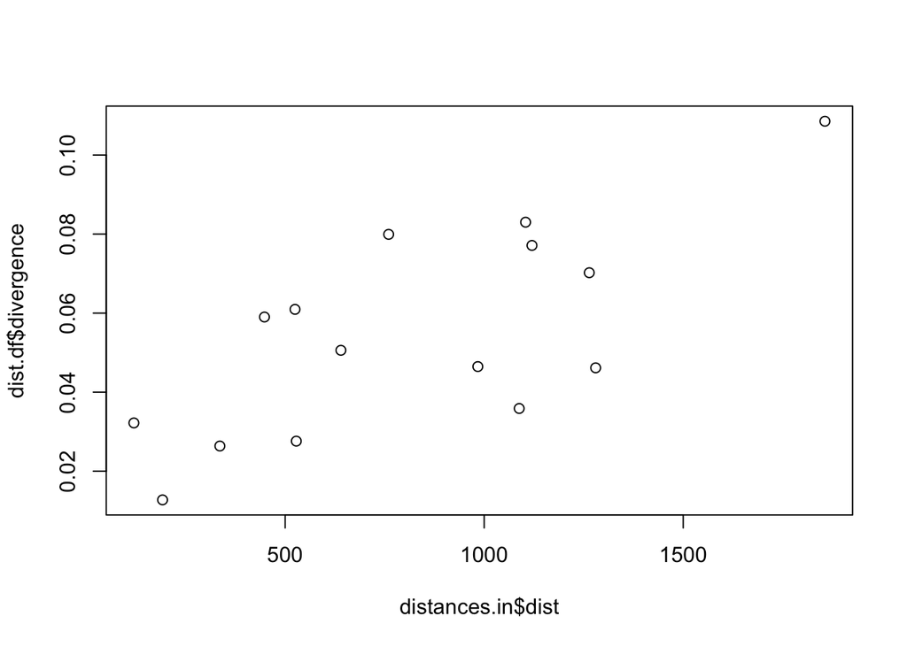

```r
#           1          2          3          4          5
#2 0.06095057
#3 0.07993336 0.01274354
#4 0.07022213 0.05059432 0.05901452
#5 0.07712645 0.02760509 0.02637039 0.03221225
#6 0.10855165 0.04615476 0.03587285 0.08300799 0.04647403

dist.out <- as.matrix(dist.out)
dimnames(dist.out) <- dimnames(dist.out) <- list(1:6, 1:6)
xy <- t(combn(colnames(dist.out), 2))
dist.df <- data.frame(pop1=xy[,1], pop2 = xy[,2], divergence=dist.out[xy])

# plot isolation by distance
urlfile<-'https://raw.githubusercontent.com/rsbrennan/EvolutionaryGenomics/master/Exercises/data/distances.txt'
distances.in <- read.table(urlfile, header=T)
plot(x=distances.in$dist, dist.df$divergence)
```

#### Question 3.2

1. Do the genetic distances between populatinos make sense given the PCA?
2. Is there evidence for isolation by distance?

### Structure

Structure takes a long time to run, so I’ve done this for you. Below you can process the output to understand the results.

You can download the files from this drive directory: https://drive.google.com/drive/folders/1C9KbEUiBFSf_zJ9Cor8piH5TN8Buh2X-?usp=sharing

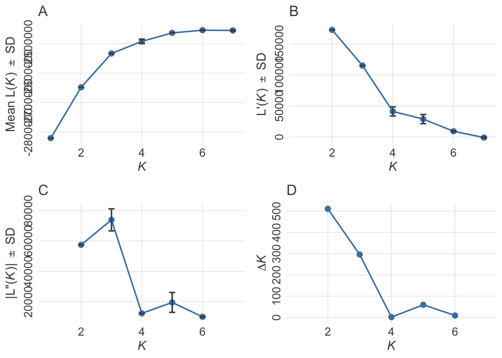

```r
###############
# structure
###############

# read in the data:
files <- list.files(path="~/Documents/GEOMAR/teaching/Mar_pop_gen/bioc_281/exercises/data/structure",
                    full.names=TRUE)
slist <- readQ(files=files, filetype="structure", indlabfromfile=T)

# create table for plotting
qlist <- (tabulateQ(slist))
# take table, make summary table
sr1 <- summariseQ(qlist)

# plot the evanno plots to determine the best number for K.
p <- evannoMethodStructure(data=sr1,exportplot=F,returnplot=T,returndata=F,basesize=12,linesize=0.7)
grid.arrange(p)
```

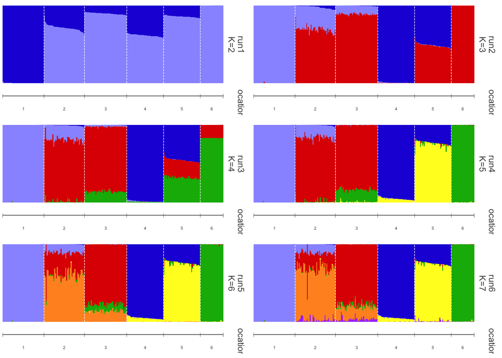

```r
# align clusters, this is just to make the plots pretty
slist <- alignK(slist)
# you have replicates, merge these for plotting
mergedS <- (mergeQ(slist))

mergedS2 <- list()

# reorder individuals. this is for clarity. you don't necessarily need to do this.
for (i in 2:length(mergedS)){
  tmpdf <- data.frame(matrix(nrow=0, ncol=ncol(mergedS[[i]])))
  colnames(tmpdf) <- colnames(mergedS[[i]])
  for (pop in c("TR", "PC", "HP", "PP", "PL", "GA")){
    tmpdf <- rbind(tmpdf,mergedS[[i]][grep(pop, row.names(mergedS[[i]])),])
  }
  mergedS2[[i-1]] <- tmpdf
}

# make group labels:
labs <- data.frame(location = substring(rownames(mergedS2[[2]]),1,2))
# replace the population names with the corresponding numbers from the map. Just to make it easier to interpret
labs$location<- gsub("TR", "1",labs$location)
labs$location<- gsub("PC", "2",labs$location)
labs$location<- gsub("HP", "3",labs$location)
labs$location<- gsub("PP", "4",labs$location)
labs$location<- gsub("PL", "5",labs$location)
labs$location<- gsub("GA", "6",labs$location)

p1 <- plotQ(as.qlist(mergedS2),returnplot=T,exportplot=F,basesize=11,
            sortind="Cluster1", grplab=labs)
grid.arrange(p1$plot[[1]], p1$plot[[2]],p1$plot[[3]],p1$plot[[4]],p1$plot[[5]],p1$plot[[6]])
```

#### Question 3.3

1. What is the most likely K? Why did you choose this value?
2. Describe the structure of the population. You can use multiple values of K to help you make sense of things.